# My SpotifyR

Author

Antonio Paulo

# Lars Huismann

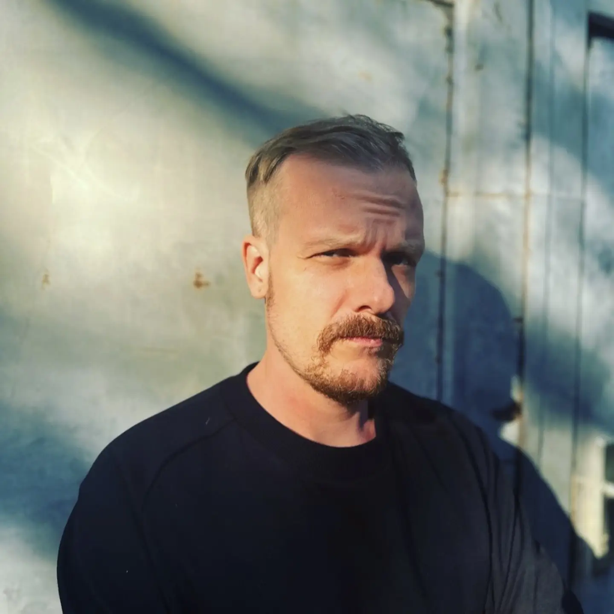

## Who is Lars Huismann?

Lars Huismann is a Berlin based techno producer.

Born in 1987 in Berlin, from a young age he had a passion for music, playing in jazz and metal bands when he was a teenager. He then transitioned to techno in the late 90s, when the techno scene in Berlin was booming. **He was there when it all started!**

Since the opening of his label LHR in 2015, we can really see the solidification of his sound and signature traits. His sound is characterized by this bigroom kick, rolling baseline and progressive beats resulting in the classic groove and hard groove techno that he is especially famous for.

# Aim

I want to analyse his tracks and have a better idea of the patterns within them, mainly **I want to understand how his sound has changed over the releases and where is he moving towards.** This will also give a very good idea of where the whole groove and hard groove techno scene is moving towards as he is a renowned producer and many big DJs often play his tracks during their sets.

# Spotify Data

## Retrieving Data

The data I had in the .csv file **only had 15 data points** which corresponded to the tracks that belong to the only 3 albums he released.

```r
# These are some of the packages that we will need for this exercise.

library(spotifyr)
library(tidyverse)
#library(devtools)
#devtools::install_github('charlie86/spotifyr')
#library(spotifyr)
library(tidyverse)
library(knitr)

#Code to access spotify data
Sys.setenv(SPOTIFY_CLIENT_ID = '909b3f7256fd48b5b063ff3d4d0630e7')
Sys.setenv(SPOTIFY_CLIENT_SECRET = 'd261f557261543c697afa624df7ec722')
access_token <- get_spotify_access_token()

#Test to see if the code above worked properly, only retireves albums, that is the default option. Therefore we must specify that we want to retrieve singles as well as albums.This results in 15 tracks.
Lars <- get_artist_audio_features('lars huismann')
Lars <- Lars |> dplyr::select(track_name, album_name)

# Load necessary libraries
library(dplyr)
library(tibble)

# This code will add a column with a number for each track.
Lars_with_row_numbers <- Lars %>%
  tibble::rownames_to_column(var = "Track number")

#Counting and displaying the number of rows
num_rows <- nrow(Lars)
print(num_rows)
```

```
[1] 15
```

```r
# Load the knitr package
library(knitr)

# Creating a table
table_output <- knitr::kable(Lars_with_row_numbers, caption = "Results from the first data retrieval", digits = 2)

# Print or display the table
print(table_output)
```

```
Table: Results from the first data retrieval

|Track number |track_name                              |album_name |
|:------------|:---------------------------------------|:----------|
|1            |Silver Surfer                           |Shift Time |
|2            |Silver Surfer - Kitkatone Remix         |Shift Time |
|3            |Silver Surfer - C-System Remix          |Shift Time |
|4            |The Machinist                           |Shift Time |
|5            |Machinist - Irrational Language Remix   |Shift Time |
|6            |Move On! - Original Mix                 |Memories   |
|7            |Memories - Original Mix                 |Memories   |
|8            |Rave Ritual - Original Mix              |Memories   |
|9            |The Mask Has Fallen - Original Mix      |Memories   |
|10           |Memories - Wunderblock ExtendedRumbaDub |Memories   |
|11           |Infect The Sound                        |Monuments  |
|12           |Methodic Cutting                        |Monuments  |
|13           |Within The Ruins                        |Monuments  |
|14           |Soul Love                               |Monuments  |
|15           |Acidic Tribalism                        |Monuments  |
```

Therefore we had to **adjust the code** so that it would **retrieve both albums and singles**. This is because the code:

LH <- get_artist_audio_features(‘lars huismann’)

only **retrieves albums by default**, thus the specification.

**With the alteration** to the code the results are completely different, we now **retrieve 121 tracks.**

```r
#Extracting all the tracks produced by Lars Huismann (LH) that are available on spotify, this retrieves 121 tracks.
LH <- get_artist_audio_features('lars huismann', include_groups = c("album", "single"))

#This deletes unwanted columns from the data set.
LH <- LH |> dplyr::select(artist_name, track_name, track_number, album_name, time_signature, album_release_year, album_release_date, valence, energy, danceability, loudness, tempo, speechiness, instrumentalness, liveness,  key_name, mode_name, key_mode, duration_ms)

# Counting and displaying the number of rows
num_rows <- nrow(LH)
print(num_rows)
```

```
[1] 121
```

```r
# Slice 5 random records in the dataframe
LH |> dplyr::slice_sample(n=5) |> knitr::kable(digits = 2)
```

| artist_name | track_name | track_number | album_name | time_signature | album_release_year | album_release_date | valence | energy | danceability | loudness | tempo | speechiness | instrumentalness | liveness | key_name | mode_name | key_mode | duration_ms |
| --- | --- | --- | --- | --- | --- | --- | --- | --- | --- | --- | --- | --- | --- | --- | --- | --- | --- | --- |
| Lars Huismann | 2600 - Escape to Mars Remix | 2 | 2600 | 4 | 2017 | 2017-07-28 | 0.33 | 0.93 | 0.60 | -7.79 | 134.01 | 0.07 | 0.90 | 0.14 | B | minor | B minor | 352745 |
| Lars Huismann | Anais | 3 | Sphere | 3 | 2014 | 2014-11-30 | 0.15 | 0.96 | 0.42 | -9.21 | 191.84 | 0.07 | 0.88 | 0.09 | C# | major | C# major | 367194 |
| Lars Huismann | Insert - Original Mix | 4 | Arikmetica EP | 4 | 2019 | 2019-07-15 | 0.06 | 0.86 | 0.70 | -8.87 | 130.01 | 0.04 | 0.91 | 0.11 | C# | major | C# major | 387692 |
| Lars Huismann | Dystopia | 1 | Fractured Realities | 4 | 2023 | 2023-11-10 | 0.81 | 0.97 | 0.71 | -7.42 | 144.00 | 0.06 | 0.87 | 0.11 | A# | minor | A# minor | 363985 |
| Lars Huismann | Nightdrive | 1 | Wasteland Memories | 4 | 2016 | 2016-09-12 | 0.44 | 0.93 | 0.72 | -6.45 | 128.01 | 0.06 | 0.86 | 0.11 | D# | minor | D# minor | 428606 |

Now that I have successfully retrieve all the data that I can start analyzing it.

# Data Analysis

## How busy has he been?

First I want to understand how many tracks Lars Huismann released per year.

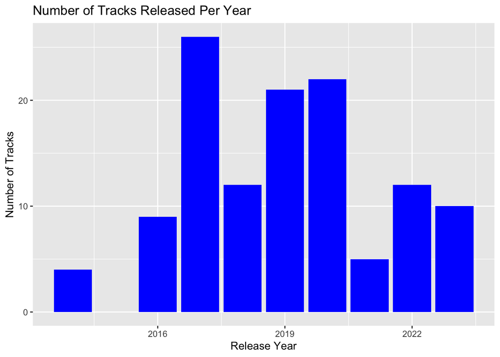

```r
#These are the packages I will need.
library(dplyr)
library(ggplot2)

#Grouping the tracks per year of release.
tracks_per_year <- LH %>%
  group_by(album_release_year) %>%
  count()

# Using ggplot2 to create a bar chart
ggplot(tracks_per_year, aes(x = album_release_year, y = n)) +
  geom_bar(stat = "identity", fill = "blue") +
  labs(title = "Number of Tracks Released Per Year",
       x = "Release Year",
       y = "Number of Tracks")
```

Here we can see that in **2017 he released 26 tracks** on Spotify which was the **highest** number of tracks he released in any given year.

**During COVID19 he was probably very bored** at home which allowed the time to produce a lot of tracks as well. And we see that **post-COVID he hasn’t released as many tracks**.

Also we see that in **2015 there were no tracks released**. That is probably because he was busy opening his label.

## Happy or Sad Lars?

Let’s look at valance to see if Lars is a happy boi or a sad boi.

**Valence shows how positive or negative a track is**, on a scale of 0 to 1. The higher the number the more positive the tracks.

Positive tracks are happy, cheerful, and euphoric.

Negative tracks are sad, depressed, angry.

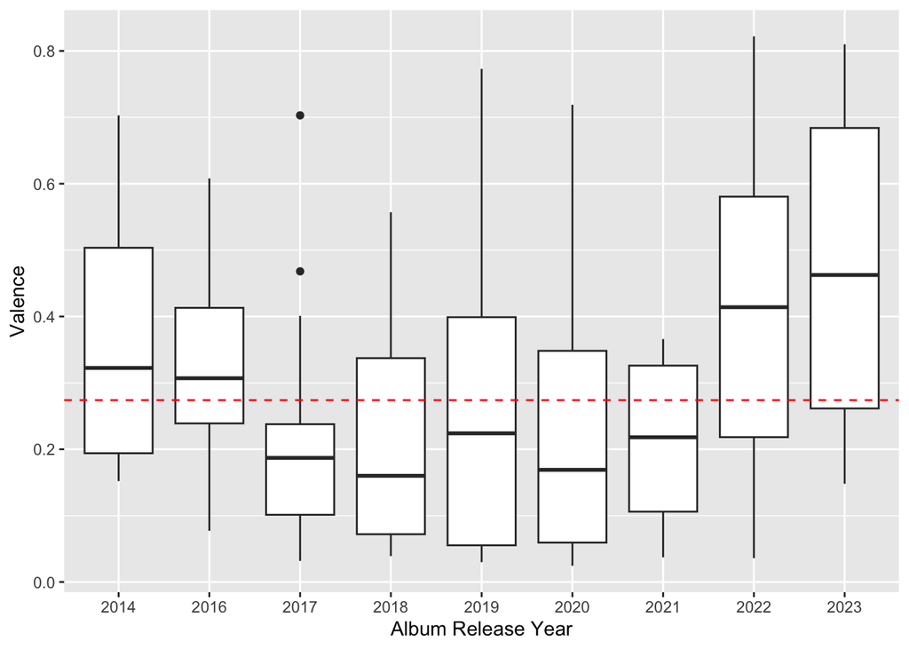

```r
# Change album_name from character to factor before plotting
LH$album_release_year <- as.factor(LH$album_release_year)

#calculating the mean valance for his tracks
av_valance <- mean(LH$valence)

# Plot a boxplot
ggplot(LH, aes(x=album_release_year, y=valence))+
  geom_boxplot()+
  geom_hline(yintercept = av_valance, linetype = "dashed", color = "red") +
  labs(x="Album Release Year", y="Valence")
```

Here we can see that:

1. There is quite some **variability in valence between the tracks released each year**. Meaning that for each year he has some songs that have a low valance and others have a high valence.
2. In general his songs are considered to be **negative** since the **average valance in close to 0.3**.
3. **Lars must have been a bit depressed or sad between 2017 and 2021** because most of the released tracks were below the average valance which was already quite negative. However they have quite some variation within each year.
4. **2023 was his most positive year** because even the lowest quartile is almostas high as the average.

### Lars is a very sad boi. But is he really?

I don’t think so. I think it is **hard to assess the happiness or sadness of techno** because of the way the tracks are composed and structured. Many follow a 4x4 beat and are quite repetitive and sometime their elements or lack thereof can seem sad or depressed or angry but in fact create the opposite emotion to the listener.

## Has he found his sound?

You see with a lot of techno producers that at the beginning of their production career they normally produce quite a variety of styles. **It takes time for you to know what you like and develop your skills and your signature sound.**

So let’s see if Lars has found his sound.

### Energy

```r
#Calculating the average energy
av_energy <- mean(LH$energy)
print(av_energy)
```

```
[1] 0.9183388
```

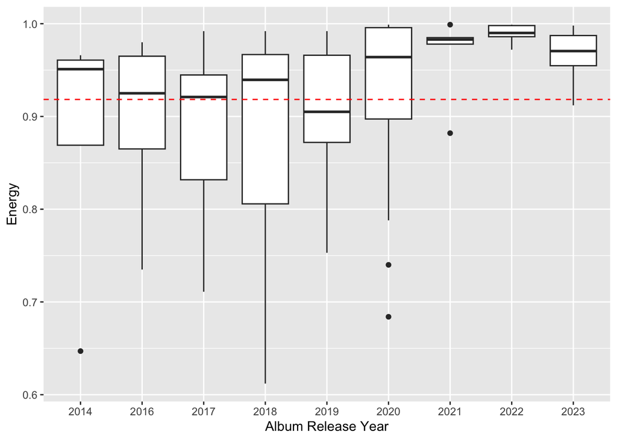

```r
ggplot(LH, aes(x=album_release_year, y=energy))+
  geom_boxplot()+
  geom_hline(yintercept = av_energy, linetype = "dashed", color = "red") +
  labs(x="Album Release Year", y="Energy")
```

Here we are looking at the energy level of the tracks released per year.

What does this tells us:

1. Before 2021 there was **quite some variation in energy levels,** compared to 2021 and after. This tells me that Lars Huismann really honed in on his sound and found his niche place within the producers of techno. This because now he is producing tracks specifically for the club scene and to be mixed with 2 or more other tracks. This can be confirmed if we see low variability between other variables such as danceability.
2. His last **3 years have produced some energetic tracks.** This is my favorite period of his.
3. In general most of **his tracks are very energetic** as he is a techno producer, with a mean energy level of 0.918.

### My hypothesis

**The hypothesis is that he honed in on his sound and found his niche spot within the techno producers.**

To see if my hypothesis is true then lets look at danceability and see if the data per year has a low variability for the years 2021, 2022, 2023.

### Danceability

Let’s see if danceability helps me prove or discard my hypothesis.

```r
#Calculating the average danceability
av_dance <- mean(LH$danceability)
print(av_dance)
```

```
[1] 0.6782314
```

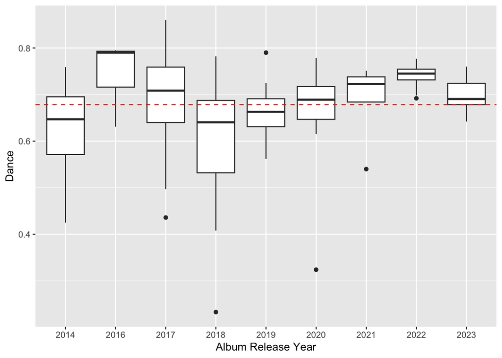

```r
ggplot(LH, aes(x=album_release_year, y=danceability))+
  geom_boxplot()+
   geom_hline(yintercept = av_dance, linetype = "dashed", color = "red") +
  labs(x="Album Release Year", y="Dance")
```

Here we can see that:

1. **The variability seems to decrease as the years go on**. You will always have some variability because all tracks are different.
2. His **average danceability score is 0.67** meaning his tracks are very danceable.
3. Since 2018, there has been an **increase in danceability** between the tracks released.
4. In the **last 3 years** (2021-2023), the **danceability** of the tracks **was above average** even when looking at the lower quartile.

This tells me that my **hypothesis might be correct** because Lars now has defined his concept of groove and danceability and is able to replicate in all the songs he releases.

It also tells me that he is really marketing his tracks to be played in clubs by djs and that they are not meant to be listened to individually but rather mixed with 2 or more tracks.

### Time Signature

Time signature describes the compass or metric of the song. Techno producers almost always exclusively work with a 4x4 metric meaning there are 4 beats per compass.

This doesn’t do much to prove my hypothesis but it is able to tell me whether or not Lats has been experimenting with counts or if he stuck to the golden rule.

```r
#Calculating the average energy
av_time_sig <- mean(LH$time_signature)
print(av_time_sig)
```

```
[1] 3.933884
```

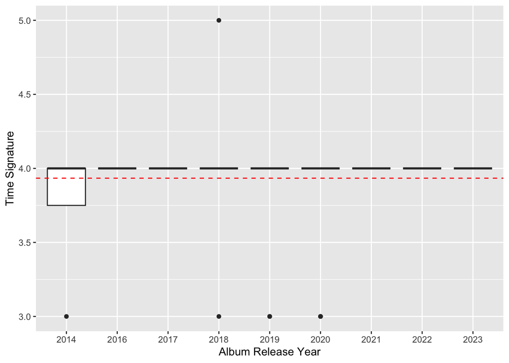

```r
ggplot(LH, aes(x=album_release_year, y=time_signature))+
  geom_boxplot()+
  geom_hline(yintercept = av_time_sig, linetype = "dashed", color = "red") +
  labs(x="Album Release Year", y="Time Signature")
```

Here we can see that **only in 2014 there was some variation** within the metrics used, meaning he was experimenting and probably what he was producing would not be considered techno but another genre of electronic music. For the rest **he sticks to the golden rule of techno which is a 4x4 metric**, although **he has an out-liar every so often**, meaning its not the norm, which is also demonstrated by the average time signature of 3.9.

## What are my favs?

So, let’s look at my favorite tracks produced by Lars Huismann.

These are my top 5:

```r
#This is a data set with my top 5 songs from LH.
top5 <- c("Cope", "Dusty Lick", "Sounds from the Past II", "Loucura", "Stroke")
# Selecting and visualizing my top 5 tracks from LH
fav_track <- LH %>% filter(track_name %in% top5) %>% knitr::kable(digits = 2)

print(fav_track)
```

```
|artist_name   |track_name              | track_number|album_name               | time_signature|album_release_year |album_release_date | valence| energy| danceability| loudness|  tempo| speechiness| instrumentalness| liveness|key_name |mode_name |key_mode | duration_ms|
|:-------------|:-----------------------|------------:|:------------------------|--------------:|:------------------|:------------------|-------:|------:|------------:|--------:|------:|-----------:|----------------:|--------:|:--------|:---------|:--------|-----------:|
|Lars Huismann |Cope                    |            3|Fractured Realities      |              4|2023               |2023-11-10         |    0.45|   0.97|         0.64|    -8.56| 143.99|        0.06|             0.91|     0.13|B        |minor     |B minor  |      430254|
|Lars Huismann |Dusty Lick              |            6|Sounds from the Past III |              4|2023               |2023-06-02         |    0.23|   1.00|         0.68|    -6.19| 145.00|        0.07|             0.91|     0.14|B        |minor     |B minor  |      305241|
|Lars Huismann |Sounds from the Past II |            1|Sounds from the Past II  |              4|2022               |2022-11-25         |    0.39|   0.99|         0.75|    -6.45| 143.95|        0.04|             0.87|     0.11|F        |major     |F major  |      315844|
|Lars Huismann |Loucura                 |            3|Sounds from the Past II  |              4|2022               |2022-11-25         |    0.82|   1.00|         0.75|    -4.25| 145.98|        0.06|             0.91|     0.09|B        |minor     |B minor  |      305572|
|Lars Huismann |Stroke                  |            4|Sounds from the Past II  |              4|2022               |2022-11-25         |    0.06|   0.98|         0.78|    -4.19| 145.02|        0.23|             0.97|     0.11|G        |major     |G major  |      294201|
```

#### Let’s have a look at my favorite track

[Soundtrack link from Spotify](https://open.spotify.com/embed/track/77GFr1ZklLcg3Yw264A4e4?utm_source=generator)

What makes them my favorite tracks?

### Danceability

Lets see if they are within the top10 most danceable tracks:

```r
#Let's look at his 10 most danceable songs
LH |> slice_max(danceability, n=10) |> dplyr::select(track_name, album_name, album_release_year, danceability) |> knitr::kable(digits = 2)
```

| track_name | album_name | album_release_year | danceability |
| --- | --- | --- | --- |
| Move On! - Original Mix | Memories | 2017 | 0.86 |
| Artefact | No Merci Ep | 2017 | 0.80 |
| Within The Ruins | Monuments | 2016 | 0.80 |
| Infect The Sound | Monuments | 2016 | 0.79 |
| Acidic Tribalism | Monuments | 2016 | 0.79 |
| Daylight - Martin Lewis Breakout Remix | Wasteland Memories | 2016 | 0.79 |
| Delirium - Original Mix | Frozen Minds | 2019 | 0.79 |
| Monuments | Wasteland Memories | 2016 | 0.79 |
| Mind Vortex | Juggernaut EP | 2017 | 0.78 |
| No Merci | No Merci Ep | 2017 | 0.78 |

They are not. Maybe danceability is not a factor I regard important.

### Tempo

Maybe tempo will have my favorite tracks, maybe I really like fast songs.

```r
#Let's look at his 10 fastest tracks
LH |> slice_max(tempo, n=10) |> dplyr::select(track_name, album_name, album_release_year, tempo) |> knitr::kable(digits = 2)
```

| track_name | album_name | album_release_year | tempo |
| --- | --- | --- | --- |
| Antimatter - Casual Treatment Remix | Antimatter | 2020 | 204.06 |
| Anais | Sphere | 2014 | 191.84 |
| Exoplanet | Exoplanet EP | 2018 | 170.72 |
| Bulletproof - AnD Remix | Take The Step | 2021 | 148.00 |
| Jackin | Sounds from the Past I | 2022 | 145.99 |
| Loucura | Sounds from the Past II | 2022 | 145.98 |
| Sounds from the Past I | Sounds from the Past I | 2022 | 145.03 |
| Split | Fractured Realities | 2023 | 145.03 |
| Propulsion | Sounds from the Past II | 2022 | 145.02 |
| Stroke | Sounds from the Past II | 2022 | 145.02 |

Well now I know that speed is a factor for whether or not I like a song, both Loucura and Stroke are within the top 10 fastest songs. **Loucura coming in 6th place with a bpm of 145.98 and Stroke coming in 10th place with a pbm of 145.02.**

### Energy

Maybe

```r
#Let's look at his 10 most energetic tracks
LH |> slice_max(energy, n=10) |> dplyr::select(track_name, album_name, album_release_year, energy) |> knitr::kable(digits = 2)
```

| track_name | album_name | album_release_year | energy |
| --- | --- | --- | --- |
| Loucura | Sounds from the Past II | 2022 | 1 |
| Dub Division | Sounds from the Past II | 2022 | 1 |
| Superfunk 1 | Superfunk 1 | 2021 | 1 |
| Cassini | Cyclops EP | 2020 | 1 |
| Dusty Lick | Sounds from the Past III | 2023 | 1 |
| Nudge | Sounds from the Past II | 2022 | 1 |
| Jackin | Sounds from the Past I | 2022 | 1 |
| Pendulum | Cyclops EP | 2020 | 1 |
| Cognitive Dissonance - Original Mix | Compromised System | 2020 | 1 |
| Centaur | Embraced By Shadows | 2020 | 1 |
| Body and Mind - Original Mix | Compromised System | 2020 | 1 |

Well here we can see that I like his more energetic songs and as we saw before most of his songs have a really high energy value.

2 of my top 5 are found on this list, of the top 10 most energetic songs. **Loucura coming in first, Dusty Lick in 5th place.**

Looking at the tables **it didnt tell me eactly what I like so much about his music.** And why my top 5 are my favorite tracks. So **let’s look at the relationship between some variable**. Maybe they will tell me more.

### Energy vs Danceability

First let me see if the increase in energy will lead to an increase in danceability.

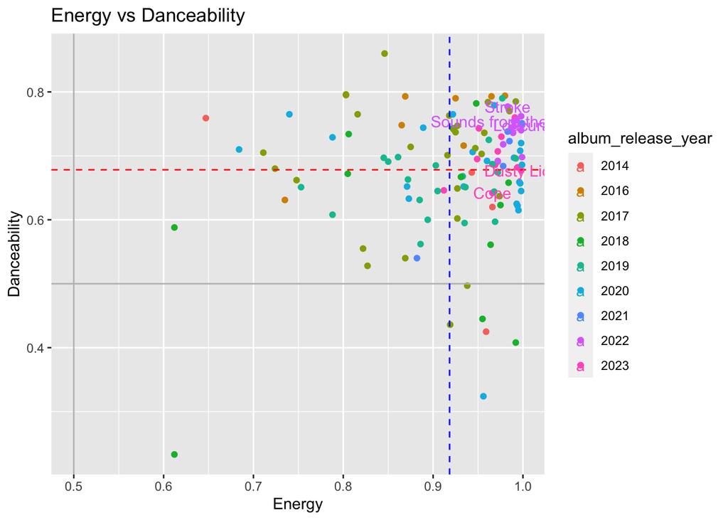

```r
#This is a data set with my top 5 songs from LH.
top5 <- LH |> filter(track_name %in% c("Cope", "Dusty Lick", "Sounds from the Past II", "Loucura", "Stroke"))
# Create a scatter plot
scatter_plot <- ggplot(LH, aes(x = energy, y = danceability, color = album_release_year)) +
  geom_point() +
  geom_hline(yintercept = 0.5, color = "grey") +
  geom_vline(xintercept = 0.5, color = "grey") +
  geom_hline(yintercept = av_dance, linetype = "dashed", color = "red") +
  geom_vline(xintercept = av_energy, linetype = "dashed", color = "blue") +
  geom_text(data=top5, aes(label=track_name)) +
  labs(title = "Energy vs Danceability",
       x = "Energy",
       y = "Danceability")

# Print or display the plot
print(scatter_plot)
```

Here we can also see that my favorite tracks are mostly above both the averages of energy and danceability. This tells me that I like the songs that are fast, have a lot of energy and are quite danceable.

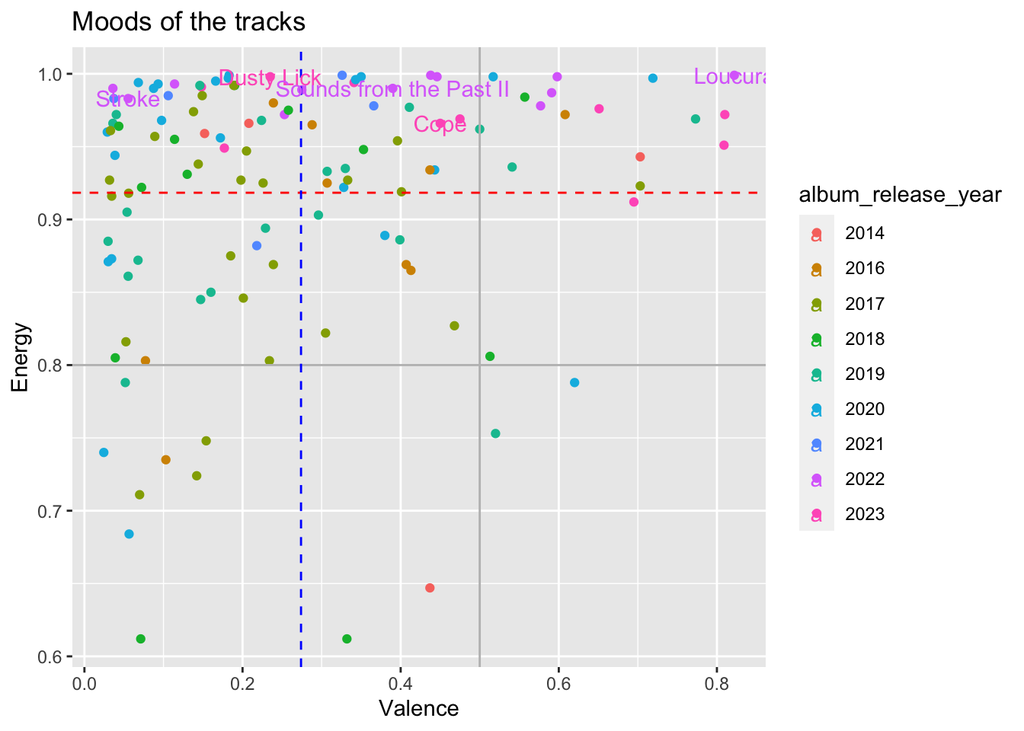

```r
#This is a data set with my top 5 songs from LH.
top5 <- LH |> filter(track_name %in% c("Cope", "Dusty Lick", "Sounds from the Past II", "Loucura", "Stroke"))
# Create a scatter plot
scatter_plot <- ggplot(LH, aes(x = valence, y = energy, color = album_release_year)) +
  geom_point() +
  geom_hline(yintercept = 0.8, color = "grey") +
  geom_vline(xintercept = 0.5, color = "grey") +
  geom_hline(yintercept = av_energy, linetype = "dashed", color = "red") +
  geom_vline(xintercept = av_valance, linetype = "dashed", color = "blue") +
  geom_text(data=top5, aes(label=track_name)) +
  labs(title = "Moods of the tracks",
       x = "Valence",
       y = "Energy")

# Print or display the plot
print(scatter_plot)
```

**Does that mean that Lars is angry? Or does it mean that I am angry?**

I don’t know about Lars but I know that for myself, whenever I listen to his songs **I don’t feel angry, in fact I feel catharsis.**

**So I think my favorite tracks from him are the tracks that give me the most catharsis.**

# Not all Producers are good Djs

Not all producers are good djs, BUT even though Lars Huismann doesn’t perform, or at least not often. He is basically solely known for producing but, there is 1 video on Youtube where he is recording a set live and he is actually pretty good.

Let’s see what groove and hard groove techno is, what techniques are used and how you use a combination of tracks to create the desired atmosphere.

**LET’S SEE THIS MASTER AT WORK.**

[video not shown]